# Time Series Notebook

### **Pacotes utilizados**

```r
library(astsa) # para analisar séries temporais
library(tsibble)  # para trabalhar com séries temporais
library(tidyverse) ### para manipulação e tratamento dos dados
library(forecast)
library(zoo)
```

```r
library(readxl)
library(ggplot2)
library(ggfortify)
library(tidyverse)
library(zoo)
library(magrittr)
library(GGally)
library(tsibble) # para trabalhar com séries temporais
library(corrplot)
library(gridExtra)
```

#### **Tratamento da base**

Primeiro carregamos a base de dados, iniciamos nossa análise com 19 variáveis e 2613 observações.

```r
MMM_data <- read_excel("MMM_data_excel.xlsx",
                                 col_types = c("text", "date", "numeric",
                                                    "numeric", "numeric", "numeric",
                                                    "numeric", "numeric", "numeric",
                                                    "numeric", "numeric", "numeric",
                                                    "numeric", "numeric", "numeric",
                                                    "numeric", "numeric", "numeric","numeric"))

head(MMM_data)
```

| TV_Manufacturing_Brand | DATE | DEMAND | CPI | CCI | PPI | Unit_Price | Supply_Data | SALES | Cost_SMS | Cost_Newspaper | Cost_Radio | Cost_TV | Cost_Internet | GRP_NewPaper | GRP_SMS | GRP_Radio | GRP_Internet | GRP_TV |
| --- | --- | --- | --- | --- | --- | --- | --- | --- | --- | --- | --- | --- | --- | --- | --- | --- | --- | --- |
| TV Manufacturing & Supplier Unit | 2010-01-01 | 4384 | 104.9 | 96.3 | 106.7 | 361.62 | 4240 | 1533269 | 77.4819 | 14.10419 | 112.3370 | 1479.457 | 722.571 | 95.333 | 11.8398 | 91.0000 | 276.3636 | 756.5909 |
| TV Manufacturing & Supplier Unit | 2010-01-02 | 4366 | 104.9 | 96.3 | 106.7 | 361.62 | 4266 | 1542671 | 73.4783 | 13.29876 | 105.7133 | 1369.891 | 717.857 | 114.957 | 27.8039 | 111.9091 | 291.3182 | 860.1364 |
| TV Manufacturing & Supplier Unit | 2010-01-03 | 4006 | 104.9 | 96.3 | 106.7 | 361.62 | 4206 | 1520974 | 80.6093 | 13.20069 | 108.7702 | 1428.064 | 653.333 | 113.090 | 0.0000 | 94.6364 | 282.7273 | 751.9545 |
| TV Manufacturing & Supplier Unit | 2010-01-04 | 4076 | 104.9 | 96.3 | 106.7 | 361.62 | 4176 | 1510125 | 65.9319 | 12.72143 | 93.3065 | 1309.355 | 622.095 | 72.442 | 0.0000 | 98.5909 | 306.3182 | 749.4545 |
| TV Manufacturing & Supplier Unit | 2010-01-05 | 4834 | 104.9 | 96.3 | 106.7 | 361.62 | 5234 | 1892719 | 77.4819 | 14.10419 | 112.3370 | 1479.457 | 722.571 | 95.333 | 11.8398 | 91.0000 | 276.3636 | 756.5909 |
| TV Manufacturing & Supplier Unit | 2010-01-06 | 4636 | 104.9 | 96.3 | 106.7 | 361.62 | 4446 | 1607763 | 73.4783 | 13.29876 | 105.7133 | 1369.891 | 717.857 | 114.957 | 27.8039 | 111.9091 | 291.3182 | 860.1364 |

```r
dim(MMM_data)
```

```
## [1] 2613   19
```

```r
str(MMM_data)
```

```
## tibble [2,613 × 19] (S3: tbl_df/tbl/data.frame)
##  $ TV_Manufacturing_Brand: chr [1:2613] "TV Manufacturing & Supplier Unit" "TV Manufacturing & Supplier Unit" "TV Manufacturing & Supplier Unit" "TV Manufacturing & Supplier Unit" ...
##  $ DATE                  : POSIXct[1:2613], format: "2010-01-01" "2010-01-02" ...
##  $ DEMAND                : num [1:2613] 4384 4366 4006 4076 4834 ...
##  $ CPI                   : num [1:2613] 105 105 105 105 105 ...
##  $ CCI                   : num [1:2613] 96.3 96.3 96.3 96.3 96.3 96.3 96.3 96.3 96.3 96.3 ...
##  $ PPI                   : num [1:2613] 107 107 107 107 107 ...
##  $ Unit_Price            : num [1:2613] 362 362 362 362 362 ...
##  $ Supply_Data           : num [1:2613] 4240 4266 4206 4176 5234 ...
##  $ SALES                 : num [1:2613] 1533269 1542671 1520974 1510125 1892719 ...
##  $ Cost_SMS              : num [1:2613] 77.5 73.5 80.6 65.9 77.5 ...
##  $ Cost_Newspaper        : num [1:2613] 14.1 13.3 13.2 12.7 14.1 ...
##  $ Cost_Radio            : num [1:2613] 112.3 105.7 108.8 93.3 112.3 ...
##  $ Cost_TV               : num [1:2613] 1479 1370 1428 1309 1479 ...
##  $ Cost_Internet         : num [1:2613] 723 718 653 622 723 ...
##  $ GRP_NewPaper          : num [1:2613] 95.3 115 113.1 72.4 95.3 ...
##  $ GRP_SMS               : num [1:2613] 11.8 27.8 0 0 11.8 ...
##  $ GRP_Radio             : num [1:2613] 91 111.9 94.6 98.6 91 ...
##  $ GRP_Internet          : num [1:2613] 276 291 283 306 276 ...
##  $ GRP_TV                : num [1:2613] 757 860 752 749 757 ...
```

### **ANÁLISE EXPLORATÓRIA**

```r
options (scipen = 999)
summary(MMM_data)
```

```
##  TV_Manufacturing_Brand      DATE                DEMAND           CPI
##  Length:2613            Min.   :2010-01-01   Min.   : 1610   Min.   :101.3
##  Class :character       1st Qu.:2011-10-16   1st Qu.: 2436   1st Qu.:101.4
##  Mode  :character       Median :2013-07-30   Median : 4636   Median :102.3
##                         Mean   :2013-07-30   Mean   : 5021   Mean   :102.6
##                         3rd Qu.:2015-05-14   3rd Qu.: 6834   3rd Qu.:103.4
##                         Max.   :2017-02-25   Max.   :18565   Max.   :106.5
##       CCI             PPI          Unit_Price     Supply_Data
##  Min.   : 96.3   Min.   : 99.5   Min.   :282.1   Min.   : 1510
##  1st Qu.:102.7   1st Qu.:100.4   1st Qu.:361.6   1st Qu.: 1776
##  Median :103.6   Median :102.7   Median :361.6   Median : 4412
##  Mean   :103.2   Mean   :102.2   Mean   :363.3   Mean   : 4523
##  3rd Qu.:104.6   3rd Qu.:103.5   3rd Qu.:361.6   3rd Qu.: 6266
##  Max.   :107.9   Max.   :107.2   Max.   :400.1   Max.   :16482
##      SALES            Cost_SMS     Cost_Newspaper    Cost_Radio
##  Min.   : 462710   Min.   :37.92   Min.   :10.03   Min.   : 62.97
##  1st Qu.: 671768   1st Qu.:47.55   1st Qu.:11.89   1st Qu.: 78.10
##  Median :1605095   Median :61.27   Median :13.19   Median : 84.13
##  Mean   :1641507   Mean   :60.39   Mean   :12.65   Mean   : 88.07
##  3rd Qu.:2267206   3rd Qu.:71.01   3rd Qu.:13.44   3rd Qu.: 98.64
##  Max.   :5960221   Max.   :89.73   Max.   :14.10   Max.   :118.47
##     Cost_TV     Cost_Internet   GRP_NewPaper         GRP_SMS
##  Min.   :1067   Min.   :   0   Min.   :   5.659   Min.   :  0.00
##  1st Qu.:1251   1st Qu.:2226   1st Qu.: 114.957   1st Qu.:  0.00
##  Median :1381   Median :3303   Median : 221.528   Median : 26.12
##  Mean   :1325   Mean   :3079   Mean   : 505.297   Mean   : 30.62
##  3rd Qu.:1416   3rd Qu.:4237   3rd Qu.: 854.310   3rd Qu.: 46.78
##  Max.   :1479   Max.   :6355   Max.   :1791.183   Max.   :145.00
##    GRP_Radio        GRP_Internet        GRP_TV
##  Min.   :  66.86   Min.   : 191.2   Min.   : 697.6
##  1st Qu.:  95.14   1st Qu.: 235.0   1st Qu.: 849.5
##  Median : 109.64   Median : 261.5   Median : 928.5
##  Mean   : 139.44   Mean   : 286.2   Mean   :1146.1
##  3rd Qu.: 126.05   3rd Qu.: 291.3   3rd Qu.:1114.9
##  Max.   :1169.41   Max.   :1540.4   Max.   :7307.3
```

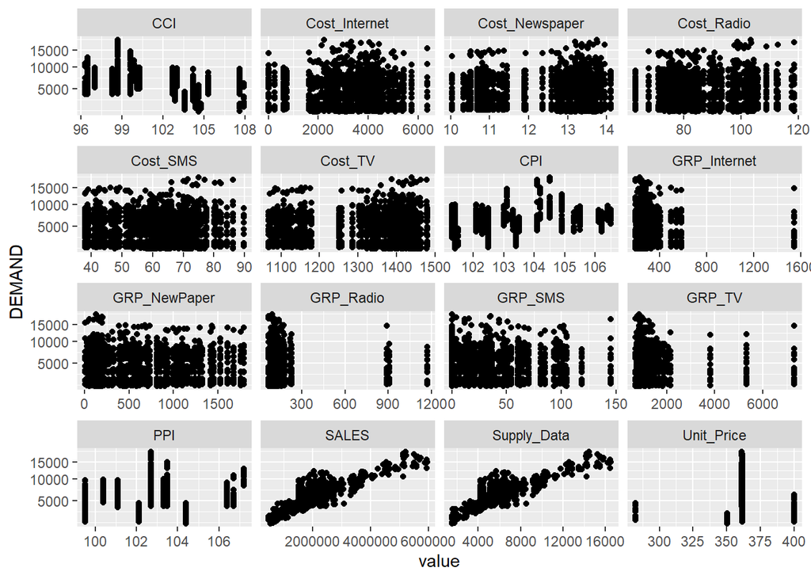

```r
MMM_nonnumeric <- MMM_data[,-c(1,2)] ### apenas valores númericos
tb <- MMM_nonnumeric %>%
  gather(key = "variable", value = "value", -DEMAND)

ggplot(tb,
       mapping = aes( x= value, y = DEMAND)) +
  facet_wrap(facets = ~variable, scale = "free_x") +
  scale_y_sqrt()+
  geom_point()
```

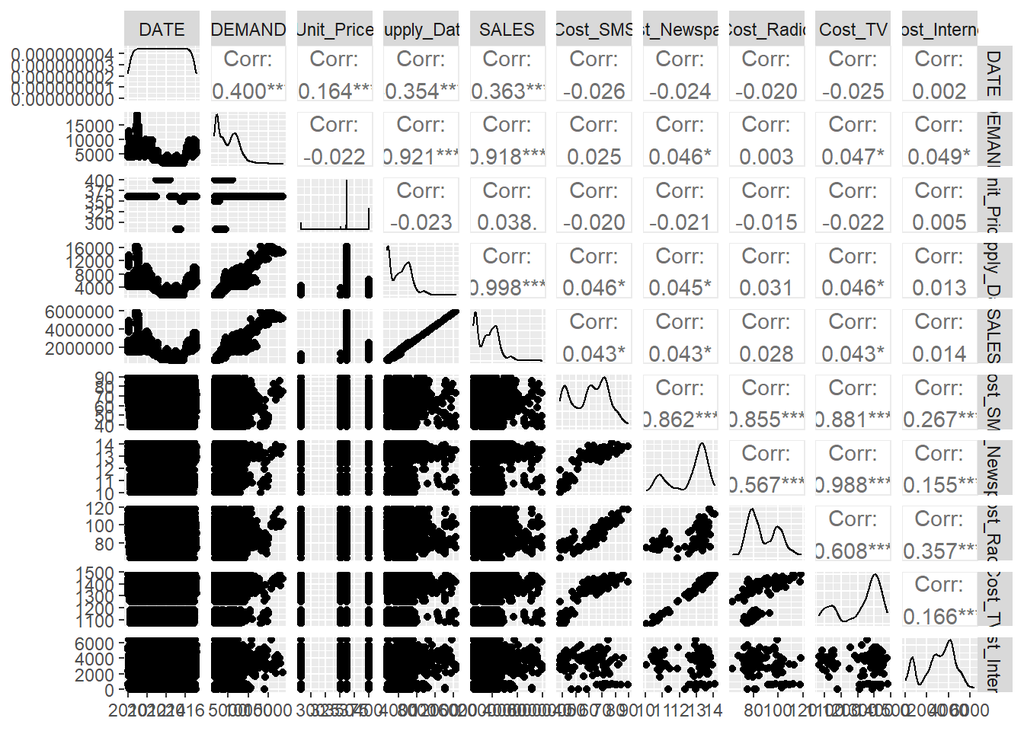

```r
MMM_cost <- MMM_data[, -c(1,4,5,6,15,16,17,18,19)] # sem os dados de GRP
ggpairs(MMM_cost)
```

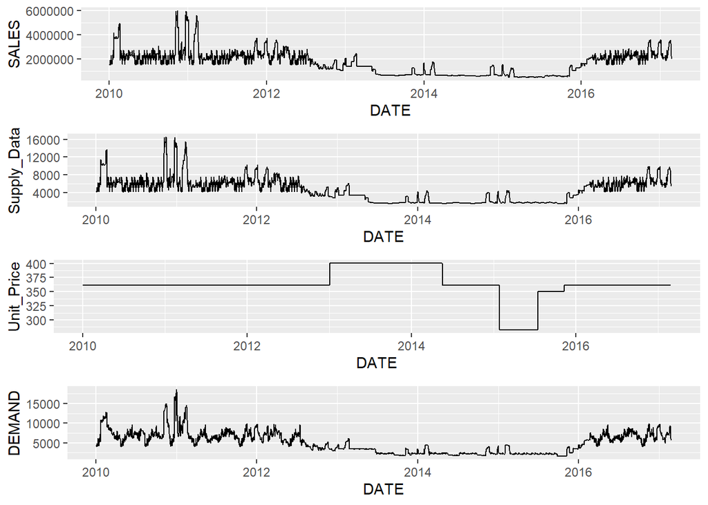

```r
## RESPOSTA ------------------------------------------

Sales <- ggplot(MMM_data, aes(x = DATE, y = SALES)) +
  geom_line()
supply <- ggplot(MMM_data, aes(x = DATE, y = Supply_Data)) +
  geom_line()
unit <- ggplot(MMM_data, aes(x = DATE, y = Unit_Price)) +
  geom_line()
demand <- ggplot(MMM_data, aes(x = DATE, y = DEMAND)) +
  geom_line()

grid.arrange(Sales, supply, unit, demand,  nrow = 4)
```

Escolhemos demanda como nossa variável resposta

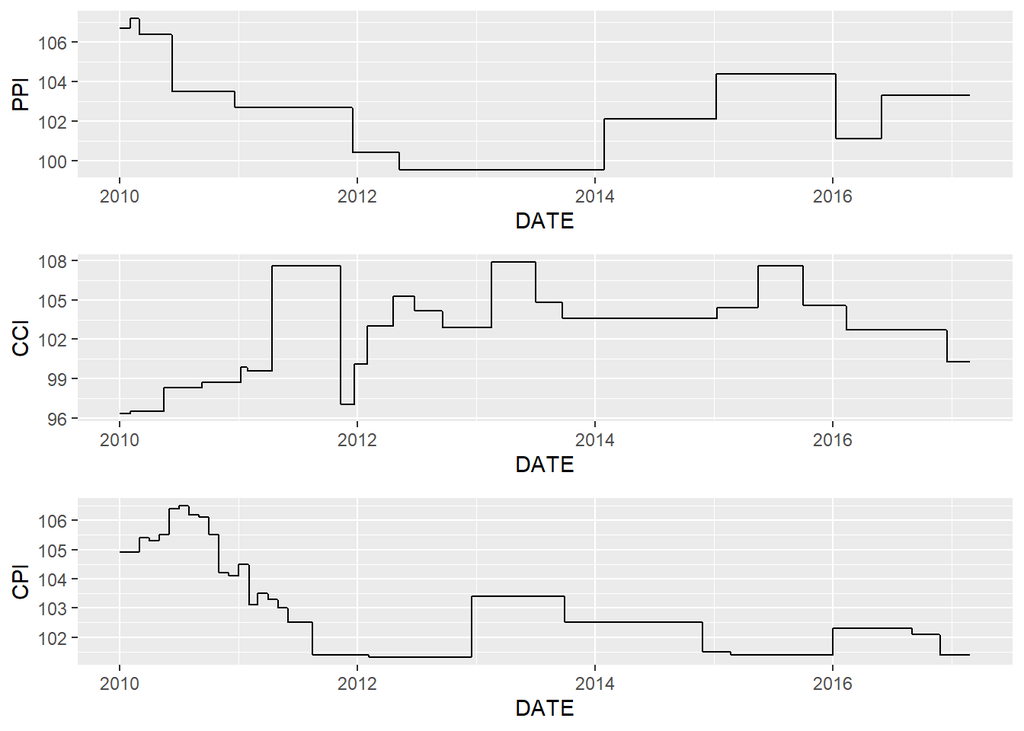

```r
## MACROECONOMICA -----------------------------------

PPI <-ggplot(MMM_data, aes(x = DATE, y = PPI)) +
  geom_line()

CCI <- ggplot(MMM_data, aes(x = DATE, y = CCI)) +
  geom_line()

CPI <- ggplot(MMM_data, aes(x = DATE, y = CPI)) +
  geom_line()

grid.arrange(PPI, CCI, CPI,  nrow = 3)
```

Como é possível observar as varipaveis estão com agregações diferentes, as variáveis macroeconomicas estão no formato mês e as demais estão diárias.

Optamos em transformar a base para o formato **mês** devido ao comportamente mensal das variaveis macroeconomicas observadas,combinado a ideia de que a série traz muitos ruídos em suas variaveis, talvez a agregação pudesse ajudar a suavizar o comportamento das outras variáveis e reduzir o ruído.

```r
# teste<-only_data %>%
#   group_by(indice_semana) %>%
#   summarise(weekly_demand = sum(DEMAND),
#             weekly_mean_unit_price=mean(Unit_Price),
#             weekly_supply_data=sum(Supply_Data),
#             weekly_sales=sum(SALES),
#             weekly_cost_sms=sum(Cost_SMS),
#             weekly_cost_newspapers=sum(Cost_Newspaper),
#             weekly_cost_radio=sum(Cost_Radio),
#             weekly_cost_tv=sum(Cost_TV))
#
#
# dia <- ggplot(MMM_data, aes(x = DATE, y = DEMAND)) +
#   geom_line()
# semana <- ggplot(teste, aes(x = indice_semana, y = weekly_demand)) +
#   geom_line()
# mes <- ggplot(teste2, aes(x = ind_mes, y = m_demand)) +
#   geom_line()
# grid.arrange(dia, semana, mes,  nrow = 3)
```

```r
str(MMM_data)
```

```
## tibble [2,613 × 19] (S3: tbl_df/tbl/data.frame)
##  $ TV_Manufacturing_Brand: chr [1:2613] "TV Manufacturing & Supplier Unit" "TV Manufacturing & Supplier Unit" "TV Manufacturing & Supplier Unit" "TV Manufacturing & Supplier Unit" ...
##  $ DATE                  : POSIXct[1:2613], format: "2010-01-01" "2010-01-02" ...
##  $ DEMAND                : num [1:2613] 4384 4366 4006 4076 4834 ...
##  $ CPI                   : num [1:2613] 105 105 105 105 105 ...
##  $ CCI                   : num [1:2613] 96.3 96.3 96.3 96.3 96.3 96.3 96.3 96.3 96.3 96.3 ...
##  $ PPI                   : num [1:2613] 107 107 107 107 107 ...
##  $ Unit_Price            : num [1:2613] 362 362 362 362 362 ...
##  $ Supply_Data           : num [1:2613] 4240 4266 4206 4176 5234 ...
##  $ SALES                 : num [1:2613] 1533269 1542671 1520974 1510125 1892719 ...
##  $ Cost_SMS              : num [1:2613] 77.5 73.5 80.6 65.9 77.5 ...
##  $ Cost_Newspaper        : num [1:2613] 14.1 13.3 13.2 12.7 14.1 ...
##  $ Cost_Radio            : num [1:2613] 112.3 105.7 108.8 93.3 112.3 ...
##  $ Cost_TV               : num [1:2613] 1479 1370 1428 1309 1479 ...
##  $ Cost_Internet         : num [1:2613] 723 718 653 622 723 ...
##  $ GRP_NewPaper          : num [1:2613] 95.3 115 113.1 72.4 95.3 ...
##  $ GRP_SMS               : num [1:2613] 11.8 27.8 0 0 11.8 ...
##  $ GRP_Radio             : num [1:2613] 91 111.9 94.6 98.6 91 ...
##  $ GRP_Internet          : num [1:2613] 276 291 283 306 276 ...
##  $ GRP_TV                : num [1:2613] 757 860 752 749 757 ...
```

```r
data_cyn<-MMM_data
head(data_cyn)
```

| TV_Manufacturing_Brand | DATE | DEMAND | CPI | CCI | PPI | Unit_Price | Supply_Data | SALES | Cost_SMS | Cost_Newspaper | Cost_Radio | Cost_TV | Cost_Internet | GRP_NewPaper | GRP_SMS | GRP_Radio | GRP_Internet | GRP_TV |
| --- | --- | --- | --- | --- | --- | --- | --- | --- | --- | --- | --- | --- | --- | --- | --- | --- | --- | --- |
| TV Manufacturing & Supplier Unit | 2010-01-01 | 4384 | 104.9 | 96.3 | 106.7 | 361.62 | 4240 | 1533269 | 77.4819 | 14.10419 | 112.3370 | 1479.457 | 722.571 | 95.333 | 11.8398 | 91.0000 | 276.3636 | 756.5909 |
| TV Manufacturing & Supplier Unit | 2010-01-02 | 4366 | 104.9 | 96.3 | 106.7 | 361.62 | 4266 | 1542671 | 73.4783 | 13.29876 | 105.7133 | 1369.891 | 717.857 | 114.957 | 27.8039 | 111.9091 | 291.3182 | 860.1364 |
| TV Manufacturing & Supplier Unit | 2010-01-03 | 4006 | 104.9 | 96.3 | 106.7 | 361.62 | 4206 | 1520974 | 80.6093 | 13.20069 | 108.7702 | 1428.064 | 653.333 | 113.090 | 0.0000 | 94.6364 | 282.7273 | 751.9545 |
| TV Manufacturing & Supplier Unit | 2010-01-04 | 4076 | 104.9 | 96.3 | 106.7 | 361.62 | 4176 | 1510125 | 65.9319 | 12.72143 | 93.3065 | 1309.355 | 622.095 | 72.442 | 0.0000 | 98.5909 | 306.3182 | 749.4545 |
| TV Manufacturing & Supplier Unit | 2010-01-05 | 4834 | 104.9 | 96.3 | 106.7 | 361.62 | 5234 | 1892719 | 77.4819 | 14.10419 | 112.3370 | 1479.457 | 722.571 | 95.333 | 11.8398 | 91.0000 | 276.3636 | 756.5909 |
| TV Manufacturing & Supplier Unit | 2010-01-06 | 4636 | 104.9 | 96.3 | 106.7 | 361.62 | 4446 | 1607763 | 73.4783 | 13.29876 | 105.7133 | 1369.891 | 717.857 | 114.957 | 27.8039 | 111.9091 | 291.3182 | 860.1364 |

```r
str(data_cyn)
```

```
## tibble [2,613 × 19] (S3: tbl_df/tbl/data.frame)
##  $ TV_Manufacturing_Brand: chr [1:2613] "TV Manufacturing & Supplier Unit" "TV Manufacturing & Supplier Unit" "TV Manufacturing & Supplier Unit" "TV Manufacturing & Supplier Unit" ...
##  $ DATE                  : POSIXct[1:2613], format: "2010-01-01" "2010-01-02" ...
##  $ DEMAND                : num [1:2613] 4384 4366 4006 4076 4834 ...
##  $ CPI                   : num [1:2613] 105 105 105 105 105 ...
##  $ CCI                   : num [1:2613] 96.3 96.3 96.3 96.3 96.3 96.3 96.3 96.3 96.3 96.3 ...
##  $ PPI                   : num [1:2613] 107 107 107 107 107 ...
##  $ Unit_Price            : num [1:2613] 362 362 362 362 362 ...
##  $ Supply_Data           : num [1:2613] 4240 4266 4206 4176 5234 ...
##  $ SALES                 : num [1:2613] 1533269 1542671 1520974 1510125 1892719 ...
##  $ Cost_SMS              : num [1:2613] 77.5 73.5 80.6 65.9 77.5 ...
##  $ Cost_Newspaper        : num [1:2613] 14.1 13.3 13.2 12.7 14.1 ...
##  $ Cost_Radio            : num [1:2613] 112.3 105.7 108.8 93.3 112.3 ...
##  $ Cost_TV               : num [1:2613] 1479 1370 1428 1309 1479 ...
##  $ Cost_Internet         : num [1:2613] 723 718 653 622 723 ...
##  $ GRP_NewPaper          : num [1:2613] 95.3 115 113.1 72.4 95.3 ...
##  $ GRP_SMS               : num [1:2613] 11.8 27.8 0 0 11.8 ...
##  $ GRP_Radio             : num [1:2613] 91 111.9 94.6 98.6 91 ...
##  $ GRP_Internet          : num [1:2613] 276 291 283 306 276 ...
##  $ GRP_TV                : num [1:2613] 757 860 752 749 757 ...
```

```r
data_cyn2<-MMM_data


data_cyn2<-MMM_data

data_cyn2$DATE <- as.Date(data_cyn2$DATE)
data_cyn2$anomes<-as.yearmon(data_cyn2$DATE, "%b-%y") %>%
    format(., "%Y-%m")


#desconsiderando apenas os dados de GRP numa nova tabela e agregando por mes
only_data2<-data_cyn2[,c(1,2,3,4,5,6,7,8,9,10,11,12,13,14,20)]
teste2<-only_data2 %>%
  group_by(anomes) %>%
  summarise(m_demand = sum(DEMAND),
            m_mean_unit_price=mean(Unit_Price),
            m_supply_data=sum(Supply_Data),
            m_sales=sum(SALES),
            m_cost_sms=sum(Cost_SMS),
            m_cost_newspapers=sum(Cost_Newspaper),
            m_cost_radio=sum(Cost_Radio),
            m_cost_tv=sum(Cost_TV),
            m_cost_internet = sum(Cost_Internet),
            m_CPI=mean(CPI),
            m_CCI=mean(CCI),
            m_PPI=mean(PPI))

library(lubridate) #inserindo indice para observações do mês
teste2$ind_mes<-seq.int(nrow(teste2))
str(teste2)
```

```
## tibble [86 × 14] (S3: tbl_df/tbl/data.frame)
##  $ anomes           : chr [1:86] "2010-01" "2010-02" "2010-03" "2010-04" ...
##  $ m_demand         : num [1:86] 209071 306495 235442 176154 201588 ...
##  $ m_mean_unit_price: num [1:86] 362 362 362 362 362 ...
##  $ m_supply_data    : num [1:86] 209908 274922 181719 195149 158908 ...
##  $ m_sales          : num [1:86] 75906931 99417294 65713225 70569781 57464311 ...
##  $ m_cost_sms       : num [1:86] 2295 1868 1683 1573 2269 ...
##  $ m_cost_newspapers: num [1:86] 414 374 386 352 414 ...
##  $ m_cost_radio     : num [1:86] 3177 2557 2432 2597 3127 ...
##  $ m_cost_tv        : num [1:86] 43548 39388 40275 36580 43706 ...
##  $ m_cost_internet  : num [1:86] 58077 87817 125260 73059 79262 ...
##  $ m_CPI            : num [1:86] 105 105 105 105 106 ...
##  $ m_CCI            : num [1:86] 96.3 96.5 96.5 96.5 97.4 ...
##  $ m_PPI            : num [1:86] 107 107 106 106 106 ...
##  $ ind_mes          : int [1:86] 1 2 3 4 5 6 7 8 9 10 ...
```

```r
head(teste2)
```

| anomes | m_demand | m_mean_unit_price | m_supply_data | m_sales | m_cost_sms | m_cost_newspapers | m_cost_radio | m_cost_tv | m_cost_internet | m_CPI | m_CCI | m_PPI | ind_mes |
| --- | --- | --- | --- | --- | --- | --- | --- | --- | --- | --- | --- | --- | --- |
| 2010-01 | 209071 | 361.62 | 209908 | 75906931 | 2295.050 | 413.5979 | 3176.842 | 43547.76 | 58076.86 | 104.9 | 96.30000 | 106.70 | 1 |
| 2010-02 | 306495 | 361.62 | 274922 | 99417294 | 1868.217 | 374.3889 | 2556.576 | 39388.19 | 87816.53 | 104.9 | 96.50000 | 107.20 | 2 |
| 2010-03 | 235442 | 361.62 | 181719 | 65713225 | 1683.111 | 386.1954 | 2431.888 | 40275.14 | 125260.19 | 105.4 | 96.50000 | 106.40 | 3 |
| 2010-04 | 176154 | 361.62 | 195149 | 70569781 | 1573.494 | 352.1607 | 2596.874 | 36579.72 | 73059.35 | 105.3 | 96.50000 | 106.40 | 4 |
| 2010-05 | 201588 | 361.62 | 158908 | 57464311 | 2269.236 | 413.8691 | 3127.449 | 43706.40 | 79261.81 | 105.5 | 97.37097 | 106.40 | 5 |
| 2010-06 | 220428 | 361.62 | 172893 | 62521567 | 1880.247 | 399.9782 | 2524.414 | 41861.72 | 106823.05 | 106.4 | 98.30000 | 104.37 | 6 |

```r
#transformando anomes em data
teste2$data<-as.Date(teste2$anomes, format = "%m/%Y")
str(teste2)
```

```
## tibble [86 × 15] (S3: tbl_df/tbl/data.frame)
##  $ anomes           : chr [1:86] "2010-01" "2010-02" "2010-03" "2010-04" ...
##  $ m_demand         : num [1:86] 209071 306495 235442 176154 201588 ...
##  $ m_mean_unit_price: num [1:86] 362 362 362 362 362 ...
##  $ m_supply_data    : num [1:86] 209908 274922 181719 195149 158908 ...
##  $ m_sales          : num [1:86] 75906931 99417294 65713225 70569781 57464311 ...
##  $ m_cost_sms       : num [1:86] 2295 1868 1683 1573 2269 ...
##  $ m_cost_newspapers: num [1:86] 414 374 386 352 414 ...
##  $ m_cost_radio     : num [1:86] 3177 2557 2432 2597 3127 ...
##  $ m_cost_tv        : num [1:86] 43548 39388 40275 36580 43706 ...
##  $ m_cost_internet  : num [1:86] 58077 87817 125260 73059 79262 ...
##  $ m_CPI            : num [1:86] 105 105 105 105 106 ...
##  $ m_CCI            : num [1:86] 96.3 96.5 96.5 96.5 97.4 ...
##  $ m_PPI            : num [1:86] 107 107 106 106 106 ...
##  $ ind_mes          : int [1:86] 1 2 3 4 5 6 7 8 9 10 ...
##  $ data             : Date[1:86], format: NA NA ...
```

```r
teste2$data<-ym(teste2$anomes)
str(teste2)
```

```
## tibble [86 × 15] (S3: tbl_df/tbl/data.frame)
##  $ anomes           : chr [1:86] "2010-01" "2010-02" "2010-03" "2010-04" ...
##  $ m_demand         : num [1:86] 209071 306495 235442 176154 201588 ...
##  $ m_mean_unit_price: num [1:86] 362 362 362 362 362 ...
##  $ m_supply_data    : num [1:86] 209908 274922 181719 195149 158908 ...
##  $ m_sales          : num [1:86] 75906931 99417294 65713225 70569781 57464311 ...
##  $ m_cost_sms       : num [1:86] 2295 1868 1683 1573 2269 ...
##  $ m_cost_newspapers: num [1:86] 414 374 386 352 414 ...
##  $ m_cost_radio     : num [1:86] 3177 2557 2432 2597 3127 ...
##  $ m_cost_tv        : num [1:86] 43548 39388 40275 36580 43706 ...
##  $ m_cost_internet  : num [1:86] 58077 87817 125260 73059 79262 ...
##  $ m_CPI            : num [1:86] 105 105 105 105 106 ...
##  $ m_CCI            : num [1:86] 96.3 96.5 96.5 96.5 97.4 ...
##  $ m_PPI            : num [1:86] 107 107 106 106 106 ...
##  $ ind_mes          : int [1:86] 1 2 3 4 5 6 7 8 9 10 ...
##  $ data             : Date[1:86], format: "2010-01-01" "2010-02-01" ...
```

```r
teste2$somes<-format(teste2$data,"%m")

teste2$soano<-format(teste2$data,"%Y")
str(teste2)
```

```
## tibble [86 × 17] (S3: tbl_df/tbl/data.frame)
##  $ anomes           : chr [1:86] "2010-01" "2010-02" "2010-03" "2010-04" ...
##  $ m_demand         : num [1:86] 209071 306495 235442 176154 201588 ...
##  $ m_mean_unit_price: num [1:86] 362 362 362 362 362 ...
##  $ m_supply_data    : num [1:86] 209908 274922 181719 195149 158908 ...
##  $ m_sales          : num [1:86] 75906931 99417294 65713225 70569781 57464311 ...
##  $ m_cost_sms       : num [1:86] 2295 1868 1683 1573 2269 ...
##  $ m_cost_newspapers: num [1:86] 414 374 386 352 414 ...
##  $ m_cost_radio     : num [1:86] 3177 2557 2432 2597 3127 ...
##  $ m_cost_tv        : num [1:86] 43548 39388 40275 36580 43706 ...
##  $ m_cost_internet  : num [1:86] 58077 87817 125260 73059 79262 ...
##  $ m_CPI            : num [1:86] 105 105 105 105 106 ...
##  $ m_CCI            : num [1:86] 96.3 96.5 96.5 96.5 97.4 ...
##  $ m_PPI            : num [1:86] 107 107 106 106 106 ...
##  $ ind_mes          : int [1:86] 1 2 3 4 5 6 7 8 9 10 ...
##  $ data             : Date[1:86], format: "2010-01-01" "2010-02-01" ...
##  $ somes            : chr [1:86] "01" "02" "03" "04" ...
##  $ soano            : chr [1:86] "2010" "2010" "2010" "2010" ...
```

```r
base_de_dados<-teste2
```

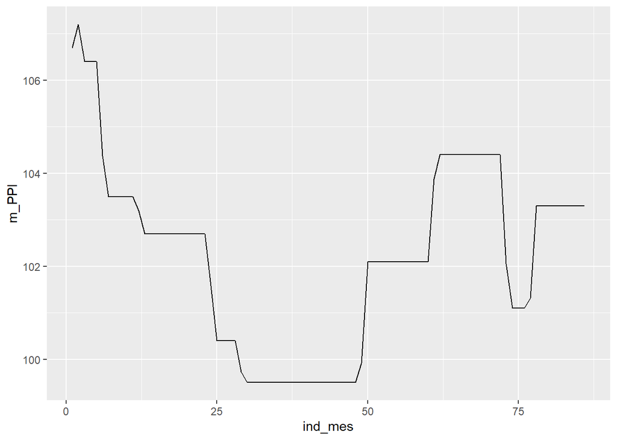

```r
### MACRO ECONOMICOS
ggplot(teste2, aes(x =ind_mes, y = m_PPI)) + geom_line()
```

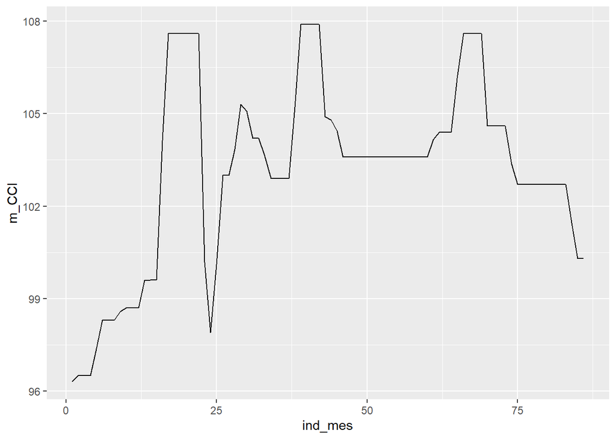

```r
ggplot(teste2, aes(x = ind_mes, y = m_CCI)) +
  geom_line()
```

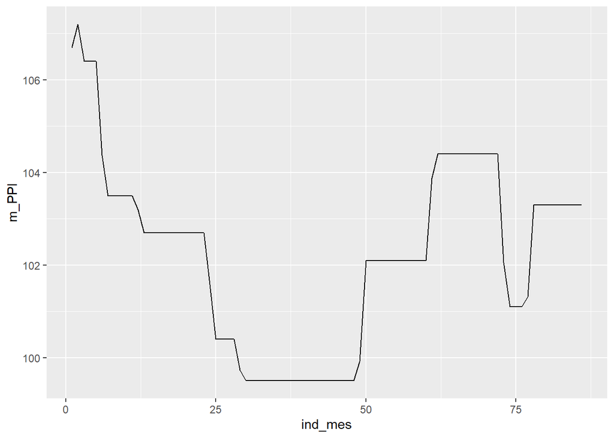

```r
ggplot(teste2, aes(x = ind_mes, y = m_PPI)) +
  geom_line()
```

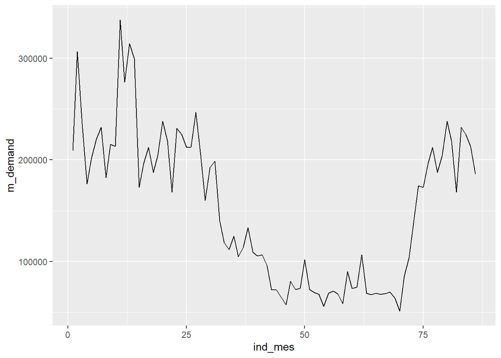

```r
## VENDAS
ggplot(teste2, aes(x = ind_mes, y = m_demand)) +
  geom_line()
```

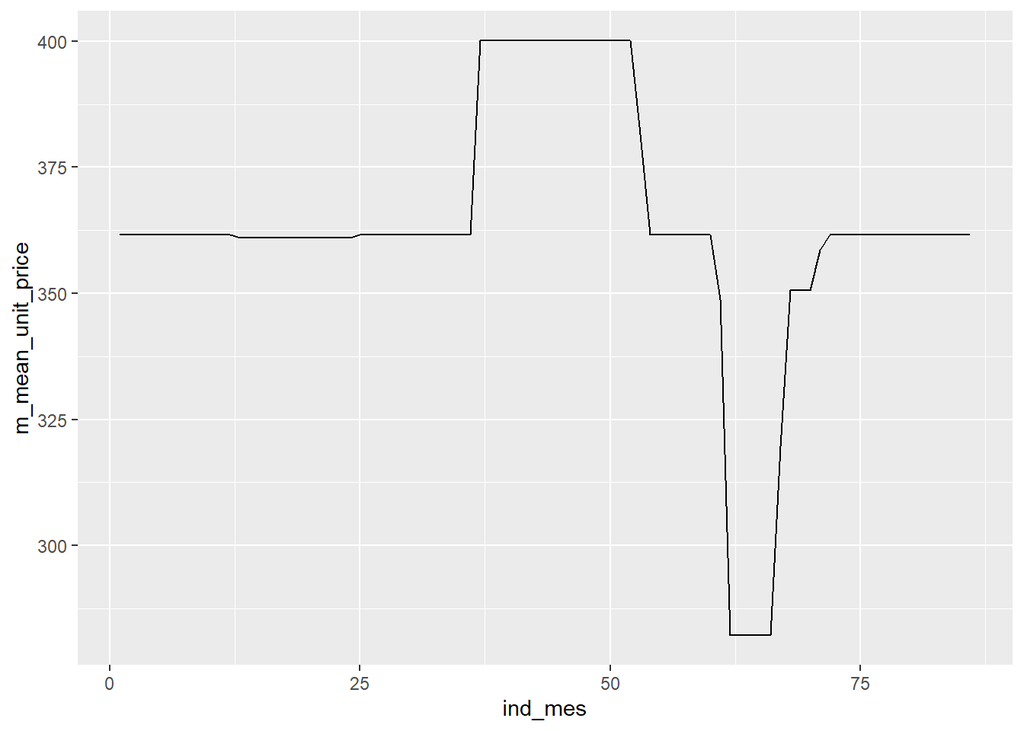

```r
ggplot(teste2, aes(x = ind_mes, y = m_mean_unit_price)) +
  geom_line()
```

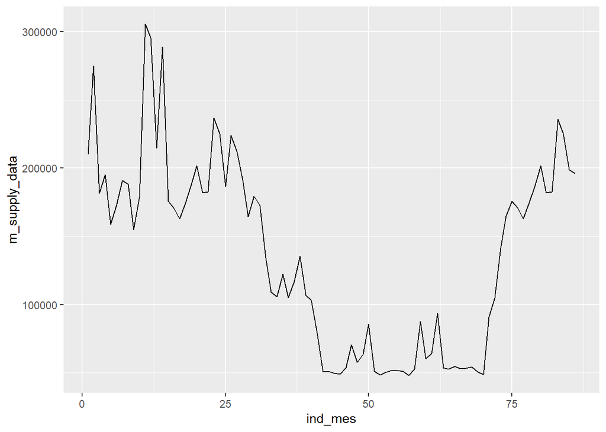

```r
ggplot(teste2, aes(x = ind_mes, y = m_supply_data)) +
  geom_line()
```

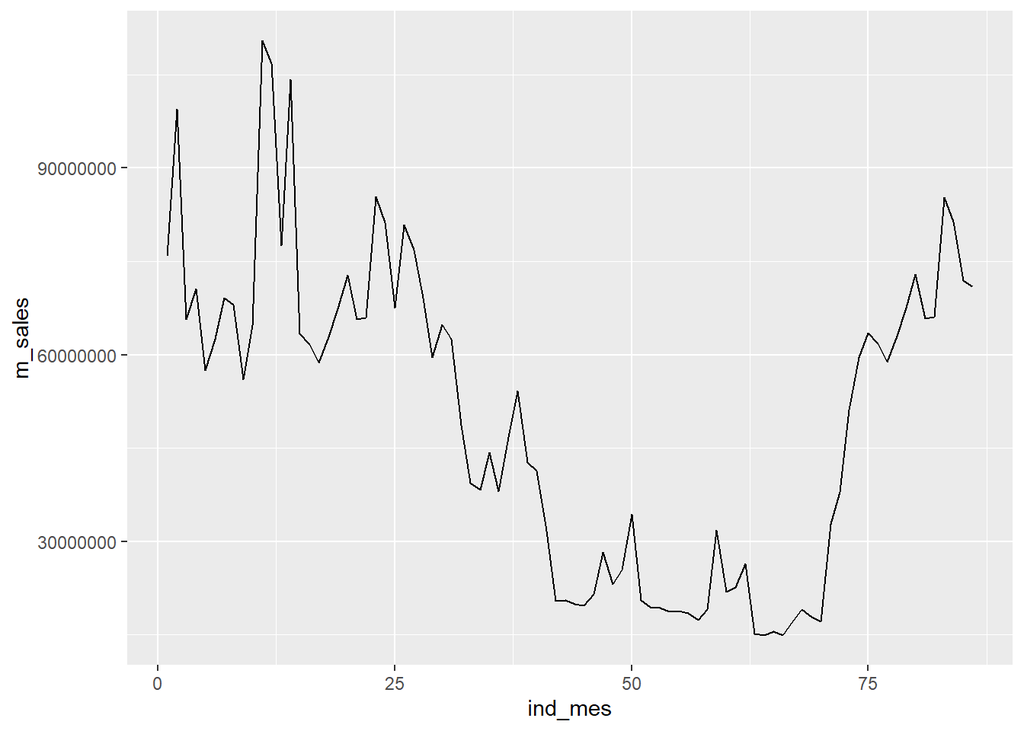

```r
ggplot(teste2, aes(x = ind_mes, y = m_sales)) +
  geom_line()
```

Aqui é visivel como a agregação nos dados reduziu o ruído nos graficos.

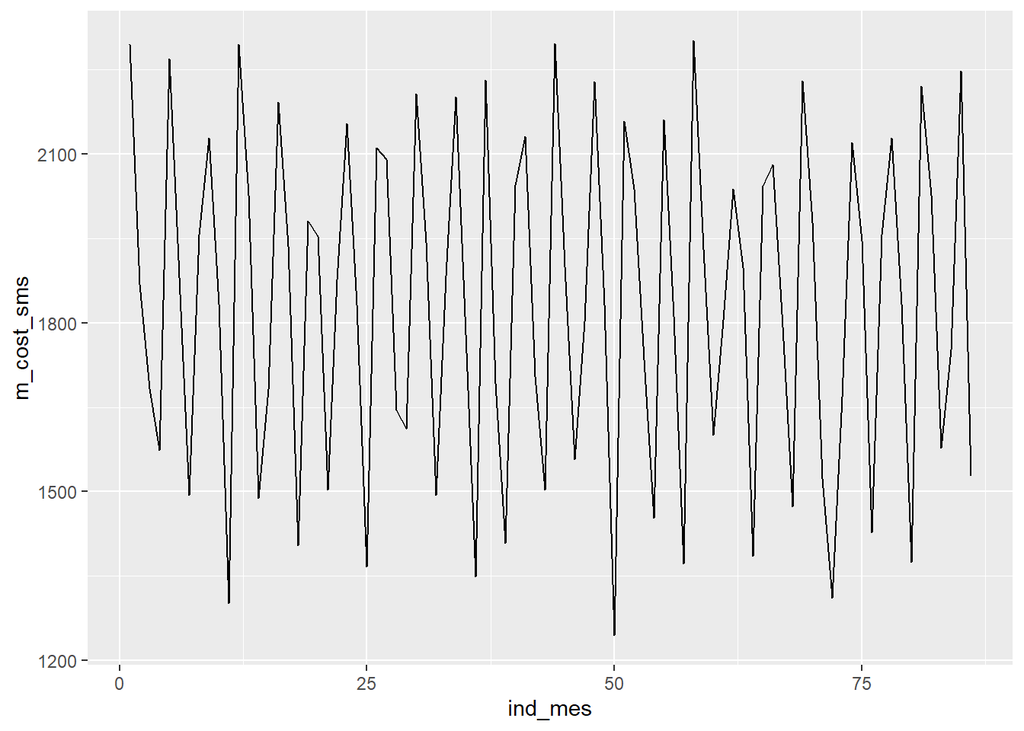

```r
##Investimento em canais
ggplot(teste2, aes(x = ind_mes, y = m_cost_sms)) +
  geom_line()
```

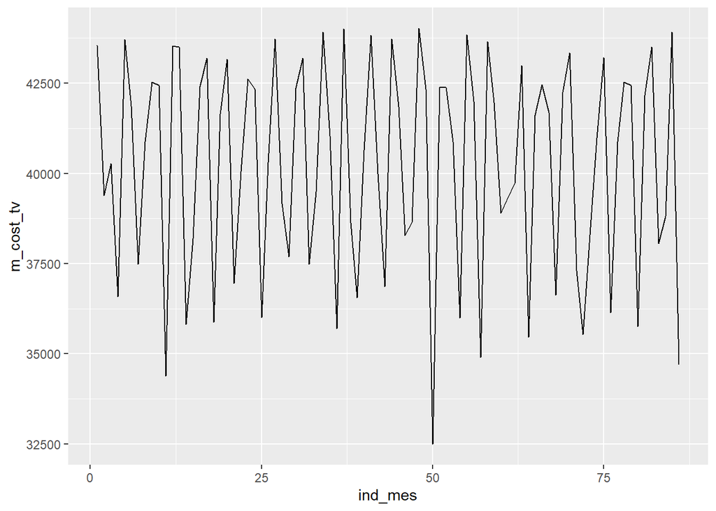

```r
ggplot(teste2, aes(x = ind_mes, y = m_cost_tv)) +
  geom_line()
```

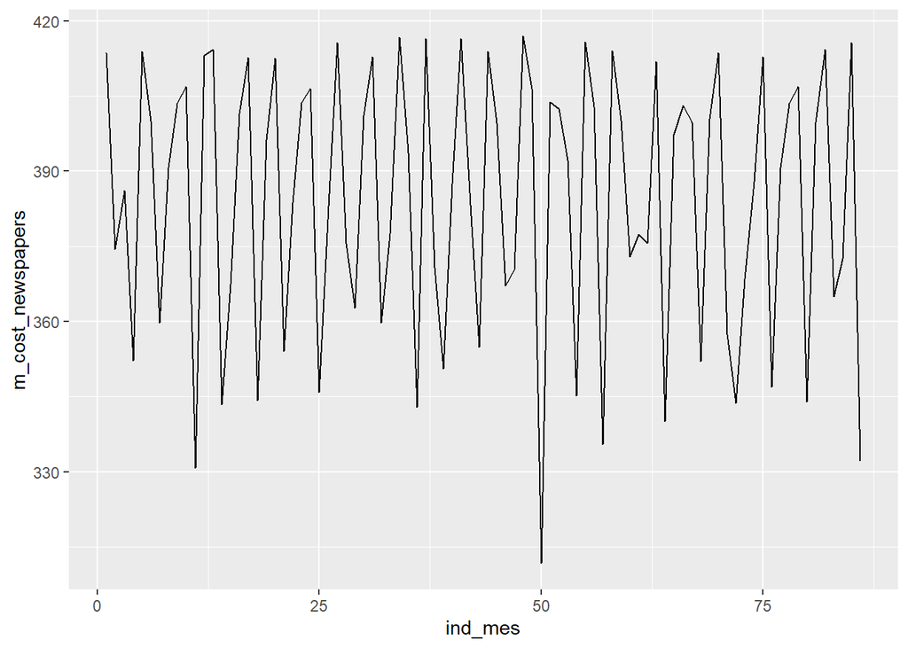

```r
ggplot(teste2, aes(x = ind_mes, y = m_cost_newspapers)) +
  geom_line()
```

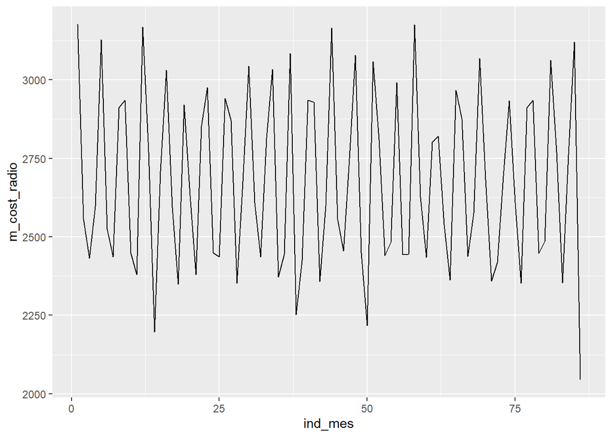

```r
ggplot(teste2, aes(x = ind_mes, y = m_cost_radio)) +
  geom_line()
```

### **ANALISE DE AUTOCORRELAÇÃO CRUZADA**

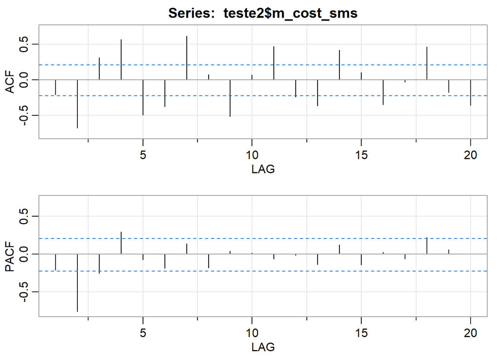

```
##       [,1]  [,2]  [,3] [,4]  [,5]  [,6] [,7]  [,8]  [,9] [,10] [,11] [,12]
## ACF  -0.21 -0.68  0.31 0.57 -0.50 -0.38 0.61  0.07 -0.52  0.07  0.46 -0.24
## PACF -0.21 -0.76 -0.25 0.29 -0.07 -0.19 0.13 -0.18  0.04  0.01 -0.07 -0.02
##      [,13] [,14] [,15] [,16] [,17] [,18] [,19] [,20]
## ACF  -0.37  0.41  0.10 -0.35 -0.04  0.46 -0.18 -0.36
## PACF -0.14  0.12 -0.14  0.02 -0.06  0.22  0.06  0.00
```

```r
acf2(teste2$m_cost_sms)##
```

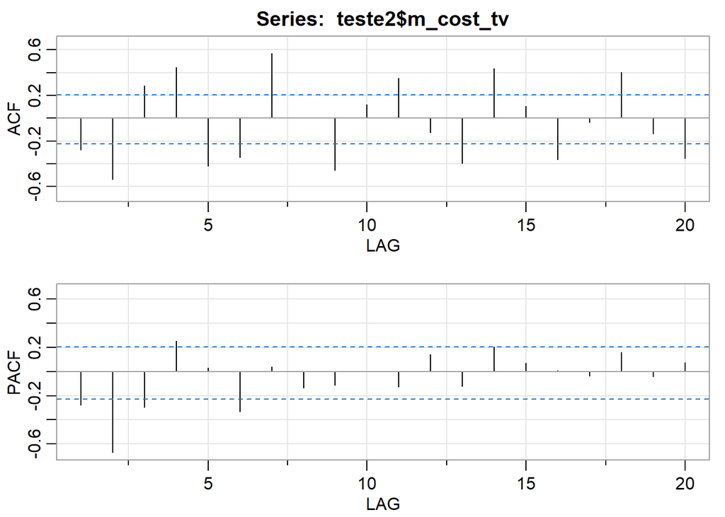

```
##       [,1]  [,2]  [,3] [,4]  [,5]  [,6] [,7]  [,8]  [,9] [,10] [,11] [,12]
## ACF  -0.28 -0.54  0.28 0.44 -0.42 -0.35 0.57  0.01 -0.46  0.12  0.35 -0.13
## PACF -0.28 -0.67 -0.29 0.25  0.03 -0.33 0.04 -0.14 -0.11  0.00 -0.12  0.14
##      [,13] [,14] [,15] [,16] [,17] [,18] [,19] [,20]
## ACF  -0.40  0.43  0.11 -0.36 -0.04  0.40 -0.14 -0.36
## PACF -0.12  0.20  0.07  0.01 -0.04  0.16 -0.04  0.07
```

```r
acf2(teste2$m_cost_tv)
```

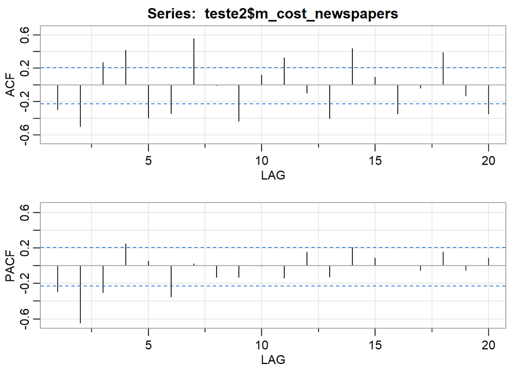

```
##      [,1]  [,2]  [,3] [,4]  [,5]  [,6] [,7]  [,8]  [,9] [,10] [,11] [,12] [,13]
## ACF  -0.3 -0.50  0.27 0.42 -0.40 -0.34 0.56 -0.01 -0.44  0.12  0.33 -0.10 -0.40
## PACF -0.3 -0.64 -0.30 0.25  0.05 -0.35 0.02 -0.13 -0.13  0.00 -0.14  0.15 -0.12
##      [,14] [,15] [,16] [,17] [,18] [,19] [,20]
## ACF   0.44  0.09 -0.35 -0.04  0.39 -0.13 -0.35
## PACF  0.21  0.09  0.00 -0.05  0.16 -0.05  0.09
```

```r
acf2(teste2$m_cost_newspapers)
```

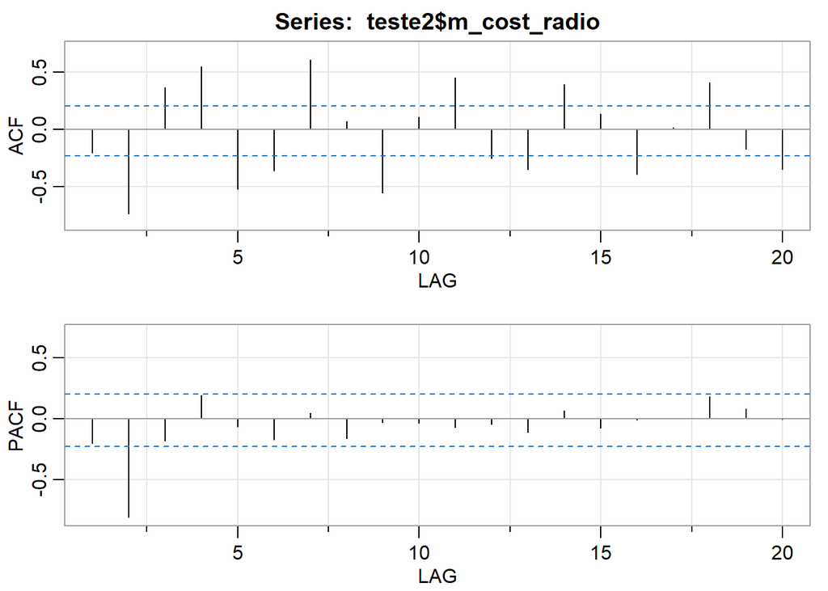

```
##      [,1]  [,2]  [,3] [,4]  [,5]  [,6] [,7]  [,8]  [,9] [,10] [,11] [,12] [,13]
## ACF  -0.2 -0.73  0.37 0.55 -0.52 -0.36 0.61  0.07 -0.55  0.11  0.45 -0.25 -0.35
## PACF -0.2 -0.81 -0.18 0.19 -0.07 -0.17 0.04 -0.16 -0.03 -0.04 -0.07 -0.04 -0.11
##      [,14] [,15] [,16] [,17] [,18] [,19] [,20]
## ACF   0.40  0.14 -0.39  0.02  0.41 -0.17 -0.35
## PACF  0.07 -0.07 -0.01  0.00  0.18  0.08  0.00
```

```r
acf2(teste2$m_cost_radio)
```

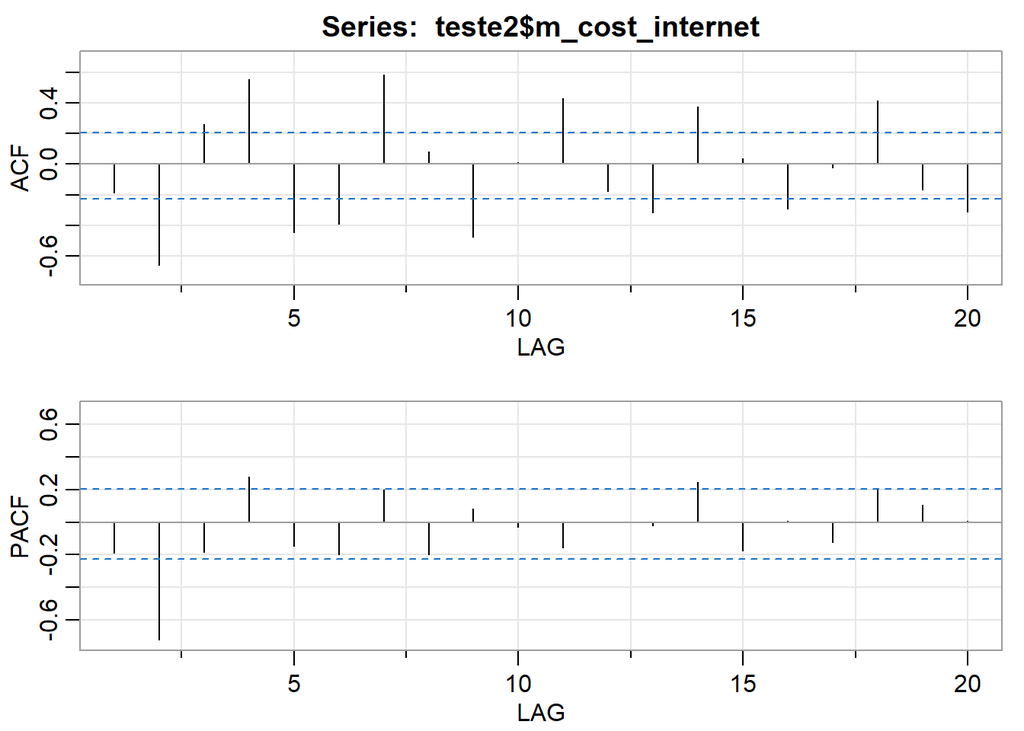

```
##       [,1]  [,2]  [,3] [,4]  [,5]  [,6] [,7]  [,8]  [,9] [,10] [,11] [,12]
## ACF  -0.19 -0.66  0.26 0.56 -0.45 -0.39 0.58  0.08 -0.48  0.01  0.43 -0.17
## PACF -0.19 -0.72 -0.19 0.28 -0.15 -0.20 0.20 -0.20  0.08 -0.03 -0.16  0.00
##      [,13] [,14] [,15] [,16] [,17] [,18] [,19] [,20]
## ACF  -0.32  0.38  0.04 -0.29 -0.02  0.42 -0.17 -0.31
## PACF -0.02  0.25 -0.18  0.01 -0.12  0.20  0.11  0.01
```

```r
acf2(teste2$m_cost_internet)
```

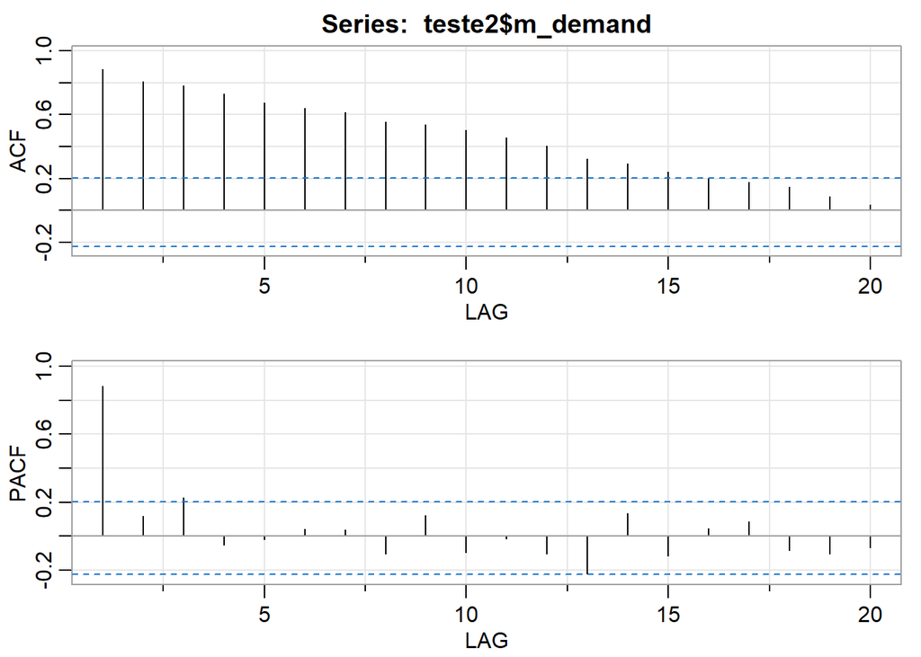

```
##      [,1] [,2] [,3]  [,4]  [,5] [,6] [,7]  [,8] [,9] [,10] [,11] [,12] [,13]
## ACF  0.88 0.81 0.78  0.73  0.67 0.64 0.61  0.56 0.54   0.5  0.46  0.40  0.32
## PACF 0.88 0.12 0.23 -0.05 -0.02 0.04 0.04 -0.10 0.12  -0.1 -0.02 -0.11 -0.22
##      [,14] [,15] [,16] [,17] [,18] [,19] [,20]
## ACF   0.29  0.24  0.20  0.18  0.15  0.09  0.04
## PACF  0.13 -0.12  0.05  0.09 -0.08 -0.11 -0.07
```

```r
acf2(teste2$m_demand)
```

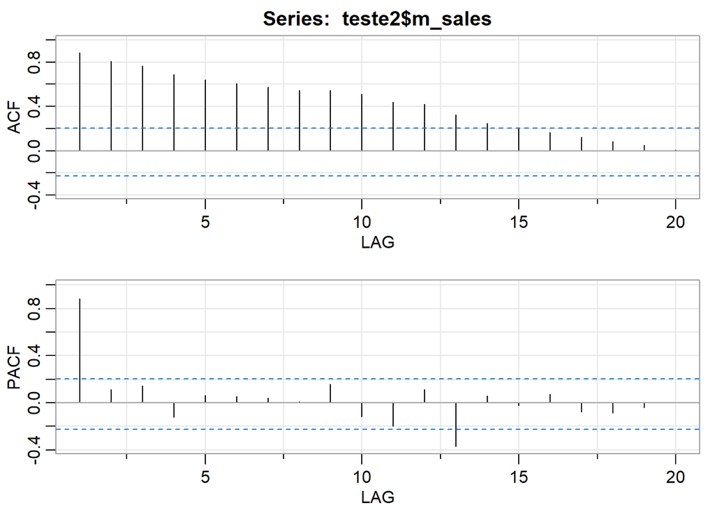

```
##      [,1] [,2] [,3]  [,4] [,5] [,6] [,7] [,8] [,9] [,10] [,11] [,12] [,13]
## ACF  0.89 0.81 0.77  0.69 0.64 0.61 0.57 0.54 0.55  0.51  0.44  0.42  0.32
## PACF 0.89 0.11 0.14 -0.12 0.06 0.05 0.04 0.01 0.16 -0.12 -0.20  0.11 -0.37
##      [,14] [,15] [,16] [,17] [,18] [,19] [,20]
## ACF   0.25  0.21  0.17  0.12  0.08  0.05  0.01
## PACF  0.06 -0.02  0.07 -0.08 -0.08 -0.04  0.01
```

```r
acf2(teste2$m_sales)
```

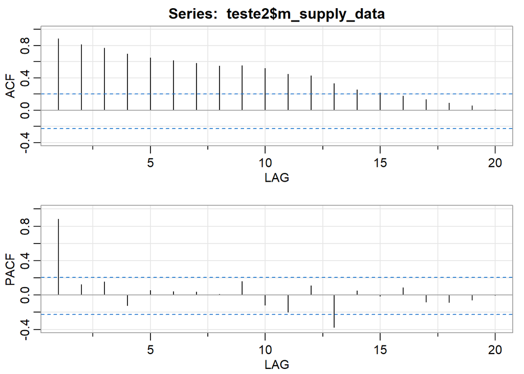

```
##      [,1] [,2] [,3]  [,4] [,5] [,6] [,7] [,8] [,9] [,10] [,11] [,12] [,13]
## ACF  0.89 0.81 0.77  0.70 0.65 0.62 0.58 0.55 0.55  0.52  0.45  0.43  0.33
## PACF 0.89 0.12 0.15 -0.12 0.06 0.04 0.04 0.01 0.16 -0.12 -0.20  0.11 -0.37
##      [,14] [,15] [,16] [,17] [,18] [,19] [,20]
## ACF   0.25  0.22  0.18  0.13  0.09  0.06  0.01
## PACF  0.05 -0.01  0.09 -0.08 -0.09 -0.06  0.00
```

```r
acf2(teste2$m_supply_data)
```

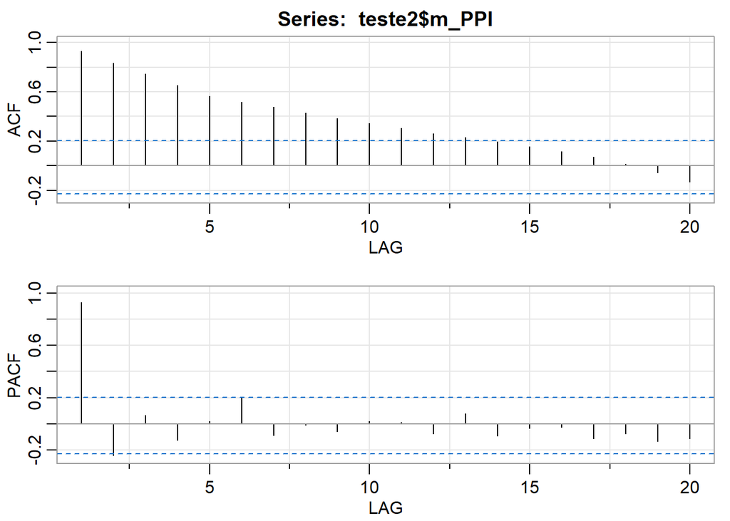

```
##      [,1]  [,2] [,3]  [,4] [,5] [,6]  [,7]  [,8]  [,9] [,10] [,11] [,12] [,13]
## ACF  0.93  0.83 0.74  0.65 0.57 0.52  0.47  0.43  0.38  0.34  0.31  0.26  0.23
## PACF 0.93 -0.24 0.07 -0.12 0.02 0.20 -0.09 -0.01 -0.06  0.02  0.01 -0.08  0.08
##      [,14] [,15] [,16] [,17] [,18] [,19] [,20]
## ACF   0.20  0.16  0.12  0.07  0.01 -0.06 -0.13
## PACF -0.09 -0.03 -0.02 -0.11 -0.07 -0.13 -0.11
```

```r
acf2(teste2$m_PPI)
```

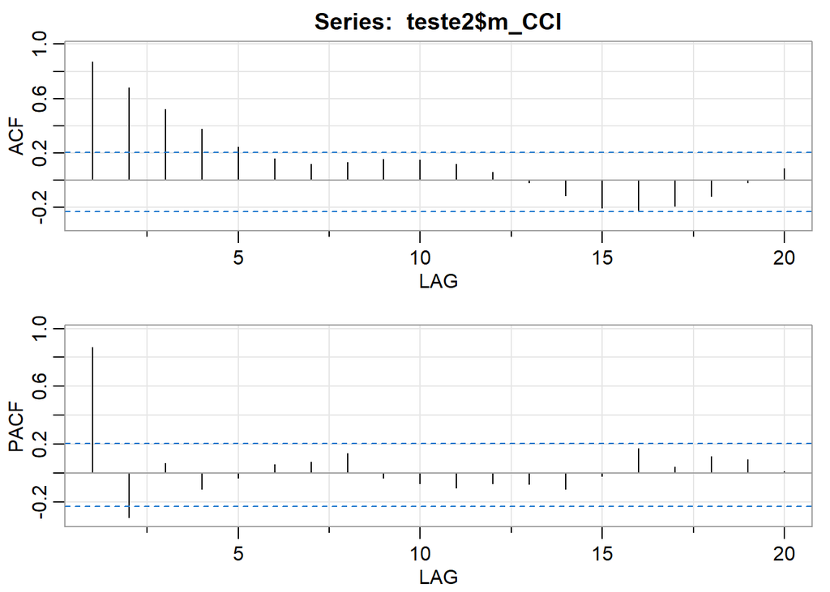

```
##      [,1]  [,2] [,3]  [,4]  [,5] [,6] [,7] [,8]  [,9] [,10] [,11] [,12] [,13]
## ACF  0.87  0.68 0.52  0.38  0.25 0.16 0.12 0.13  0.15  0.15  0.12  0.06 -0.01
## PACF 0.87 -0.31 0.07 -0.11 -0.04 0.06 0.08 0.14 -0.03 -0.07 -0.10 -0.07 -0.08
##      [,14] [,15] [,16] [,17] [,18] [,19] [,20]
## ACF  -0.11 -0.20 -0.22 -0.19 -0.12 -0.02  0.09
## PACF -0.11 -0.02  0.17  0.04  0.12  0.10  0.01
```

```r
acf2(teste2$m_CCI)
```

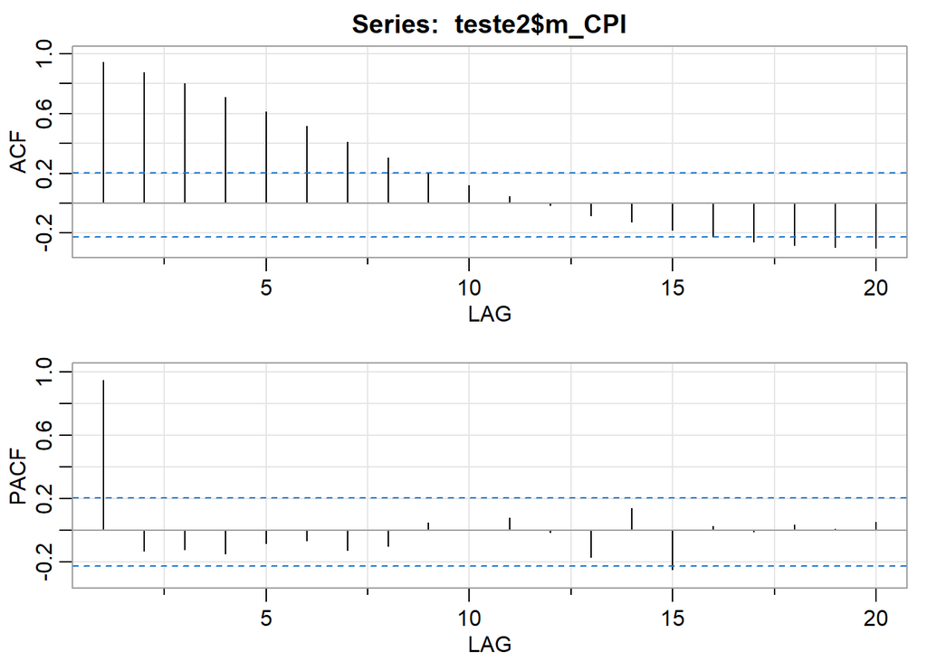

```
##      [,1]  [,2]  [,3]  [,4]  [,5]  [,6]  [,7] [,8] [,9] [,10] [,11] [,12] [,13]
## ACF  0.94  0.88  0.80  0.71  0.62  0.52  0.41  0.3 0.21  0.12  0.05 -0.01 -0.08
## PACF 0.94 -0.13 -0.12 -0.15 -0.08 -0.06 -0.13 -0.1 0.05  0.00  0.08 -0.01 -0.17
##      [,14] [,15] [,16] [,17] [,18] [,19] [,20]
## ACF  -0.13 -0.18 -0.23 -0.26 -0.28 -0.30 -0.30
## PACF  0.14 -0.25  0.03 -0.01  0.03  0.01  0.05
```

```r
acf2(teste2$m_CPI)
```

Olhando para o ACF de demanda podemos ver que talvez seja necessário trabalhar com diferença para tornar os dados estacionários.

### **TRANSFORMAND DADOS EM SERIES TEMPORAIS**

```r
dados_mes <- read_excel("dados_mensais.xlsx")
# dados em formato de séries temporais
str(dados_mes)
```

```
## tibble [86 × 17] (S3: tbl_df/tbl/data.frame)
##  $ anomes           : chr [1:86] "2010-01" "2010-02" "2010-03" "2010-04" ...
##  $ m_demand         : num [1:86] 209071 306495 235442 176154 201588 ...
##  $ m_mean_unit_price: num [1:86] 362 362 362 362 362 ...
##  $ m_supply_data    : num [1:86] 209908 274922 181719 195149 158908 ...
##  $ m_sales          : num [1:86] 75906931 99417294 65713225 70569781 57464311 ...
##  $ m_cost_sms       : num [1:86] 2295 1868 1683 1573 2269 ...
##  $ m_cost_newspapers: num [1:86] 414 374 386 352 414 ...
##  $ m_cost_radio     : num [1:86] 3177 2557 2432 2597 3127 ...
##  $ m_cost_tv        : num [1:86] 43548 39388 40275 36580 43706 ...
##  $ m_cost_internet  : num [1:86] 58077 87817 125260 73059 79262 ...
##  $ m_CPI            : num [1:86] 105 105 105 105 106 ...
##  $ m_CCI            : num [1:86] 96.3 96.5 96.5 96.5 97.4 ...
##  $ m_PPI            : num [1:86] 107 107 106 106 106 ...
##  $ ind_mes          : num [1:86] 1 2 3 4 5 6 7 8 9 10 ...
##  $ data             : POSIXct[1:86], format: "2010-01-01" "2010-02-01" ...
##  $ somes            : chr [1:86] "01" "02" "03" "04" ...
##  $ soano            : chr [1:86] "2010" "2010" "2010" "2010" ...
```

```r
dados_mes_ts<-ts(dados_mes, frequency=12, start=c(2010,1))
str(dados_mes_ts)
```

```
##  Time-Series [1:86, 1:17] from 2010 to 2017: 1 2 3 4 5 6 7 8 9 10 ...
##  - attr(*, "dimnames")=List of 2
##   ..$ : NULL
##   ..$ : chr [1:17] "anomes" "m_demand" "m_mean_unit_price" "m_supply_data" ...
```

```r
head(dados_mes_ts)
```

```
##          anomes m_demand m_mean_unit_price m_supply_data  m_sales m_cost_sms
## Jan 2010      1   209071            361.62        209908 75906931   2295.050
## Feb 2010      2   306495            361.62        274922 99417294   1868.217
## Mar 2010      3   235442            361.62        181719 65713225   1683.111
## Apr 2010      4   176154            361.62        195149 70569781   1573.494
## May 2010      5   201588            361.62        158908 57464311   2269.236
## Jun 2010      6   220428            361.62        172893 62521567   1880.247
##          m_cost_newspapers m_cost_radio m_cost_tv m_cost_internet m_CPI
## Jan 2010          413.5979     3176.842  43547.76        58076.86 104.9
## Feb 2010          374.3889     2556.576  39388.19        87816.53 104.9
## Mar 2010          386.1954     2431.888  40275.14       125260.19 105.4
## Apr 2010          352.1607     2596.874  36579.72        73059.35 105.3
## May 2010          413.8691     3127.449  43706.40        79261.81 105.5
## Jun 2010          399.9782     2524.414  41861.72       106823.05 106.4
##             m_CCI  m_PPI ind_mes       data somes soano
## Jan 2010 96.30000 106.70       1 1262304000     1     1
## Feb 2010 96.50000 107.20       2 1264982400     2     1
## Mar 2010 96.50000 106.40       3 1267401600     3     1
## Apr 2010 96.50000 106.40       4 1270080000     4     1
## May 2010 97.37097 106.40       5 1272672000     5     1
## Jun 2010 98.30000 104.37       6 1275350400     6     1
```

```r
str(dados_mes_ts)
```

```
##  Time-Series [1:86, 1:17] from 2010 to 2017: 1 2 3 4 5 6 7 8 9 10 ...
##  - attr(*, "dimnames")=List of 2
##   ..$ : NULL
##   ..$ : chr [1:17] "anomes" "m_demand" "m_mean_unit_price" "m_supply_data" ...
```

### **DECOMPOSIÇÃO**

```r
########### PARA VARIAVEL RESPOSTA ###################

ts_demanda<-ts(dados_mes$m_demand, frequency=12, start=c(2010,1))
str(ts_demanda)
```

```
##  Time-Series [1:86] from 2010 to 2017: 209071 306495 235442 176154 201588 ...
```

```r
head(ts_demanda)
```

```
##         Jan    Feb    Mar    Apr    May    Jun
## 2010 209071 306495 235442 176154 201588 220428
```

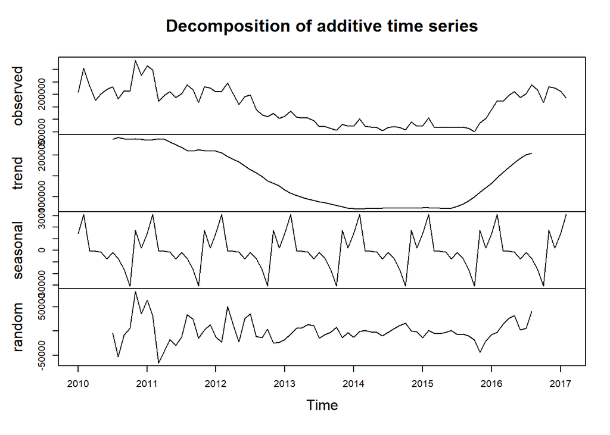

```r
dadossazonais<- decompose(ts_demanda)
plot(dadossazonais)
```

```r
##### VERIFICAR PARA OUTRAS VARIÁVEIS ################################


#####   trocar variavel para verificar decomposição
dados_mes_ts<-ts(dados_mes$m_cost_internet, frequency=12, start=c(2010,1))
str(dados_mes_ts)
```

```
##  Time-Series [1:86] from 2010 to 2017: 58077 87817 125260 73059 79262 ...
```

```r
head(dados_mes_ts)
```

```
##            Jan       Feb       Mar       Apr       May       Jun
## 2010  58076.86  87816.53 125260.19  73059.35  79261.81 106823.05
```

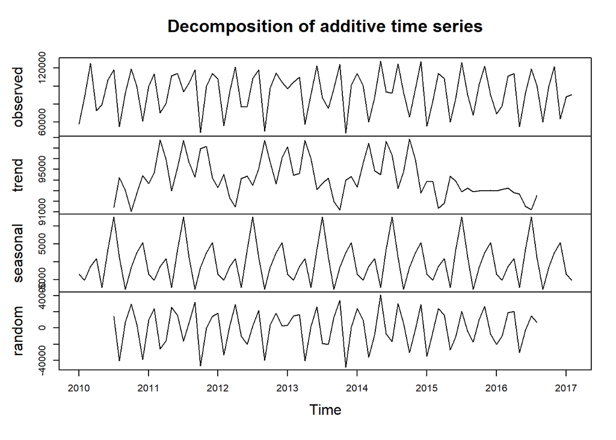

```r
sazidata<- decompose(dados_mes_ts)
plot(sazidata)
```

## **TSLM**

##### ANÁLISE DE REGRESSÃO MULTIPLA

```r
rm1 <- lm(m_demand ~ m_PPI + m_CCI + m_CPI + m_sales + m_supply_data + m_mean_unit_price +
            m_cost_sms +  m_cost_newspapers + m_cost_radio + m_cost_tv + m_cost_internet,
            data = dados_mes)

summary(rm1)
```

```
##
## Call:
## lm(formula = m_demand ~ m_PPI + m_CCI + m_CPI + m_sales + m_supply_data +
##     m_mean_unit_price + m_cost_sms + m_cost_newspapers + m_cost_radio +
##     m_cost_tv + m_cost_internet, data = dados_mes)
##
## Residuals:
##    Min     1Q Median     3Q    Max
## -37446  -7040   -581   8915  62021
##
## Coefficients:
##                          Estimate      Std. Error t value Pr(>|t|)
## (Intercept)       -1098701.516091   286603.638758  -3.834 0.000263 ***
## m_PPI                 -194.495024     1320.249501  -0.147 0.883283
## m_CCI                 1546.885720      898.409938   1.722 0.089283 .
## m_CPI                 7474.944844     1895.865196   3.943 0.000181 ***
## m_sales                 -0.006931        0.003351  -2.068 0.042090 *
## m_supply_data            3.523864        1.213788   2.903 0.004865 **
## m_mean_unit_price      347.874579      232.925029   1.494 0.139557
## m_cost_sms            -121.401931       54.988469  -2.208 0.030359 *
## m_cost_newspapers    -7056.572734     3226.213566  -2.187 0.031883 *
## m_cost_radio            -9.988100       20.521850  -0.487 0.627905
## m_cost_tv               76.044892       33.986057   2.238 0.028262 *
## m_cost_internet         -0.199733        0.245553  -0.813 0.418598
## ---
## Signif. codes:  0 '***' 0.001 '**' 0.01 '*' 0.05 '.' 0.1 ' ' 1
##
## Residual standard error: 16940 on 74 degrees of freedom
## Multiple R-squared:  0.9539, Adjusted R-squared:  0.947
## F-statistic: 139.2 on 11 and 74 DF,  p-value: < 0.00000000000000022
```

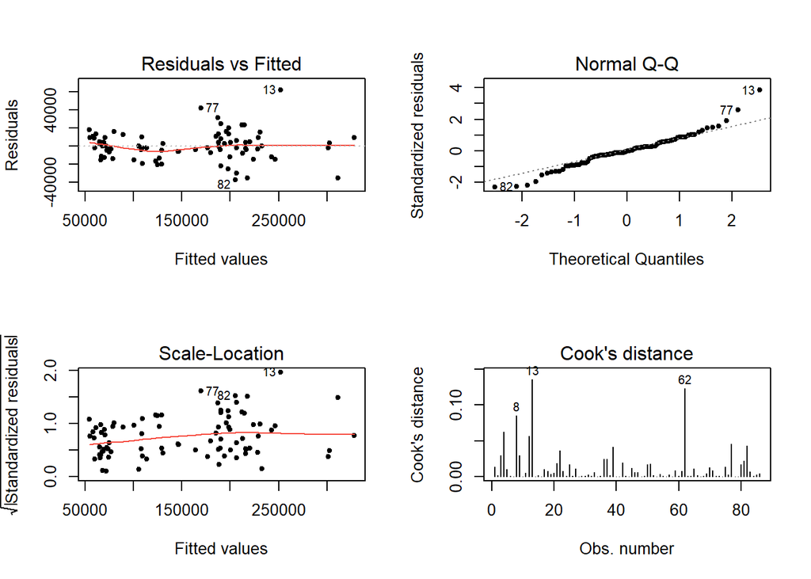

```r
par(mfrow = c(2,2))
plot(rm1, which = c(1:4), pch = 20)
```

```r
rm2 <- lm(m_demand ~ m_CCI + m_CPI + m_sales + m_supply_data + m_mean_unit_price +
            m_cost_sms +  m_cost_newspapers + m_cost_radio + m_cost_tv + m_cost_internet,
          data = dados_mes)

summary(rm2)
```

```
##
## Call:
## lm(formula = m_demand ~ m_CCI + m_CPI + m_sales + m_supply_data +
##     m_mean_unit_price + m_cost_sms + m_cost_newspapers + m_cost_radio +
##     m_cost_tv + m_cost_internet, data = dados_mes)
##
## Residuals:
##    Min     1Q Median     3Q    Max
## -37724  -6932   -593   8614  62187
##
## Coefficients:
##                          Estimate      Std. Error t value  Pr(>|t|)
## (Intercept)       -1113395.026503   266930.176586  -4.171 0.0000806 ***
## m_CCI                 1567.884304      881.226078   1.779   0.07926 .
## m_CPI                 7371.891965     1750.559537   4.211 0.0000699 ***
## m_sales                 -0.006888        0.003316  -2.077   0.04122 *
## m_supply_data            3.508409        1.201333   2.920   0.00461 **
## m_mean_unit_price      354.747961      226.711024   1.565   0.12185
## m_cost_sms            -121.902020       54.524461  -2.236   0.02834 *
## m_cost_newspapers    -7077.258305     3202.066065  -2.210   0.03014 *
## m_cost_radio            -9.924680       20.383081  -0.487   0.62774
## m_cost_tv               76.279886       33.726463   2.262   0.02661 *
## m_cost_internet         -0.200015        0.243939  -0.820   0.41485
## ---
## Signif. codes:  0 '***' 0.001 '**' 0.01 '*' 0.05 '.' 0.1 ' ' 1
##
## Residual standard error: 16820 on 75 degrees of freedom
## Multiple R-squared:  0.9539, Adjusted R-squared:  0.9477
## F-statistic: 155.1 on 10 and 75 DF,  p-value: < 0.00000000000000022
```

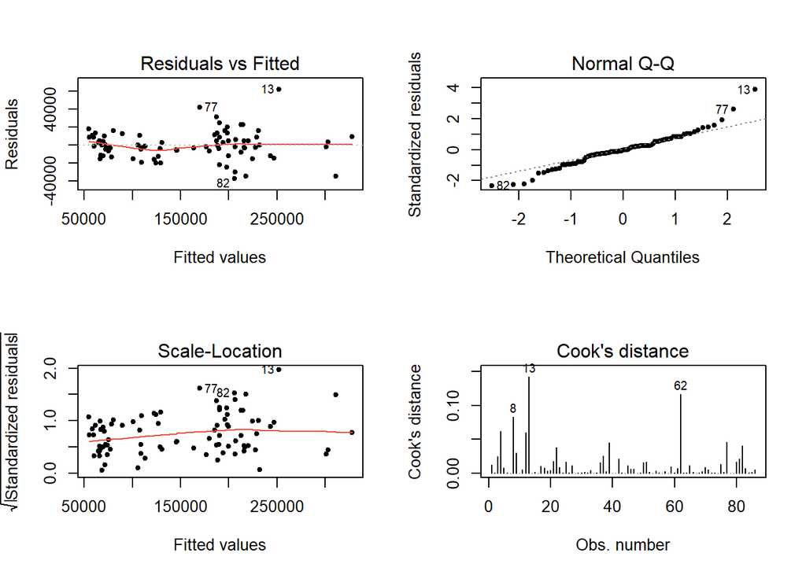

```r
par(mfrow = c(2,2))
plot(rm2, which = c(1:4), pch = 20)
```

```r
rm3 <- lm(m_demand ~ m_CCI + m_CPI + m_sales + m_supply_data + m_mean_unit_price +
            m_cost_sms +  m_cost_newspapers + m_cost_tv + m_cost_internet,
          data = dados_mes)

summary(rm3)
```

```
##
## Call:
## lm(formula = m_demand ~ m_CCI + m_CPI + m_sales + m_supply_data +
##     m_mean_unit_price + m_cost_sms + m_cost_newspapers + m_cost_tv +
##     m_cost_internet, data = dados_mes)
##
## Residuals:
##    Min     1Q Median     3Q    Max
## -37258  -7764   -591   8707  62654
##
## Coefficients:
##                          Estimate      Std. Error t value  Pr(>|t|)
## (Intercept)       -1126801.088978   264170.406528  -4.265 0.0000568 ***
## m_CCI                 1567.829498      876.791851   1.788   0.07774 .
## m_CPI                 7353.468282     1741.344014   4.223 0.0000662 ***
## m_sales                 -0.006780        0.003292  -2.059   0.04289 *
## m_supply_data            3.470787        1.192813   2.910   0.00474 **
## m_mean_unit_price      346.866339      224.994539   1.542   0.12731
## m_cost_sms            -117.385818       53.459389  -2.196   0.03116 *
## m_cost_newspapers    -6342.399346     2809.870293  -2.257   0.02687 *
## m_cost_tv               68.662361       29.728037   2.310   0.02362 *
## m_cost_internet         -0.123531        0.185694  -0.665   0.50791
## ---
## Signif. codes:  0 '***' 0.001 '**' 0.01 '*' 0.05 '.' 0.1 ' ' 1
##
## Residual standard error: 16740 on 76 degrees of freedom
## Multiple R-squared:  0.9537, Adjusted R-squared:  0.9482
## F-statistic:   174 on 9 and 76 DF,  p-value: < 0.00000000000000022
```

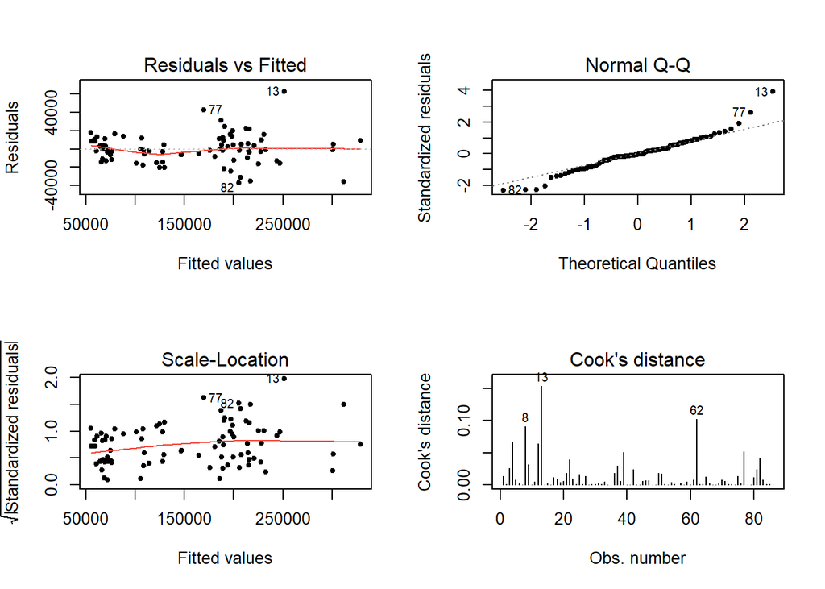

```r
par(mfrow = c(2,2))
plot(rm3, which = c(1:4), pch = 20)
```